# Protein A vs Control Protein B with treatment 1, 2 and 3

### 8A. View them in a histogram to check for distribution

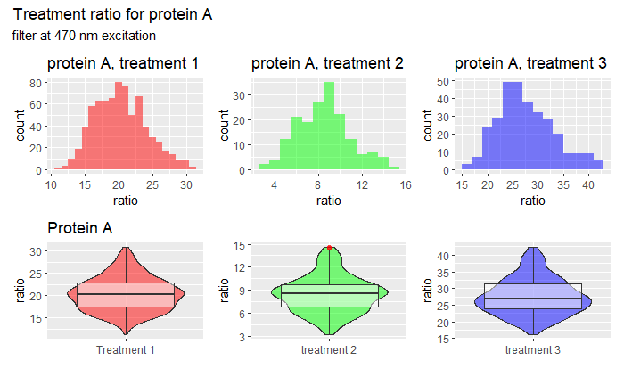

```r
set.seed(0)
# Protein A treatment 1
violinplot_clean_pAt1 <- pAt1 %>%
  ggplot(aes(x = "Treatment 1", y = ratio)) +
  geom_violin(alpha=0.5,fill = "red") + geom_boxplot(outlier.color="red", alpha=0.5) +
  xlab("")

violinplot_clean_pAt2 <- pAt2 %>%
  ggplot(aes(x = "treatment 2", y = ratio)) +
  geom_violin(alpha=0.5,fill = "green") + geom_boxplot(outlier.color="red", alpha=0.5) +
  xlab("")


violinplot_clean_pAt3 <- pAt3 %>%
  ggplot(aes(x = "treatment 3", y = ratio)) +
  geom_violin(alpha=0.5,fill = "blue") + geom_boxplot(outlier.color="red", alpha=0.5) +
  xlab("")

#--------------------------------------------------------------------
set.seed(5)
hist_pAt1 <- ggplot(pAt1,aes(ratio)) +
  geom_histogram(fill = "red", alpha = 0.5, binwidth = 1) +
  labs(title = "protein A, treatment 1")

hist_pAt2 <- ggplot(pAt2,aes(ratio)) +
  geom_histogram(fill = "green", alpha = 0.5, binwidth = 1) +
  labs(title = "protein A, treatment 2")

hist_pAt3 <- ggplot(pAt3,aes(ratio)) +
  geom_histogram(fill = "blue", alpha = 0.5, binwidth = 2) +
  labs(title = "protein A, treatment 3")

hist_pAt1 + hist_pAt2 + hist_pAt3 + violinplot_clean_pAt1 + ggtitle(label = "Protein A") + violinplot_clean_pAt2 + violinplot_clean_pAt3 + plot_layout(ncol=3,nrow=2) +
   plot_annotation(
  title = 'Treatment ratio for protein A',
  subtitle = 'filter at 470 nm excitation')# Plotting next to each other with patchwork
```

```r
NA
NA
```

### 9A. Visualizing normality assumption with Q-Q plot

```r
set.seed(900)

par(mfrow = c(1,3))
qqnorm(pAt1$ratio, main = 'Protein A treatment 1')
qqline(pAt1$ratio, col = "steelblue", lwd = 2)
```

```r
qqnorm(pAt2$ratio, main = 'Protein A treatment 2')
qqline(pAt2$ratio, col = "steelblue", lwd = 2)
```

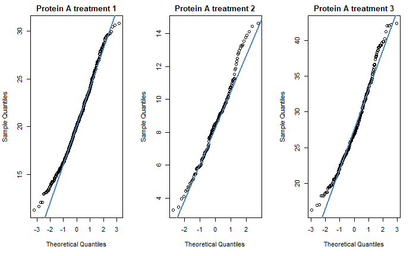

```r
qqnorm(pAt3$ratio, main = 'Protein A treatment 3')
qqline(pAt3$ratio, col = "steelblue", lwd = 2)
```

### 10A. Testing for normality of data

```r
# Testing for normality with the shapiro-Wilk test
shapiro.test(pAt1$ratio)
```

```
    Shapiro-Wilk normality test

data:  pAt1$ratio
W = 0.98774, p-value = 7.936e-06
```

```r
shapiro.test(pAt2$ratio)
```

```
    Shapiro-Wilk normality test

data:  pAt2$ratio
W = 0.98428, p-value = 0.04856
```

```r
shapiro.test(pAt3$ratio)
```

```
    Shapiro-Wilk normality test

data:  pAt3$ratio
W = 0.97543, p-value = 3.633e-05
```

### 11A. Transformation of data with log() and testing normality

```r
# log() transformations
pAt1 <- pAt1  %>%
              mutate(log_ratio = log(ratio))
shapiro.test(pAt1$log_ratio) # 0.01342
```

```
    Shapiro-Wilk normality test

data:  pAt1$log_ratio
W = 0.99481, p-value = 0.01342
```

```r
pAt2 <- pAt2  %>%
              mutate(log_ratio = log(ratio))
shapiro.test(pAt2$log_ratio) # 0.02112
```

```
    Shapiro-Wilk normality test

data:  pAt2$log_ratio
W = 0.9815, p-value = 0.02112
```

```r
pAt3 <- pAt3  %>%
              mutate(log_ratio = log(ratio))
shapiro.test(pAt3$log_ratio) # 0.1924
```

```
    Shapiro-Wilk normality test

data:  pAt3$log_ratio
W = 0.99342, p-value = 0.1924
```

### 12A. Combine data

Data will be combined in the long-format for hypothesis testing

```r
combined_pA <- rbind(pAt1,pAt2,pAt3)
```

### 13A. Checking the statistics of the cleaned data

```r
group_by(combined_pA, treatment) %>%
  summarise(
    count = n(),
    mean = mean(ratio),
    sd = sd(ratio),
    median = median(ratio),
    IQR = IQR(ratio)
  )
```

| treatment | count | mean | sd | median | IQR |
| --- | --- | --- | --- | --- | --- |
| 1 | 735 | 20.294422 | 3.786518 | 20.16 | 5.435 |
| 2 | 173 | 8.503931 | 2.386036 | 8.52 | 2.980 |
| 3 | 311 | 27.635338 | 5.521893 | 26.89 | 7.525 |

### 14A. Hypothesis testing: non-parametric Kruskal-Wallis ANOVA

Note that the difference is important in order to have a working protein. The higher the ratio, then the protein indicates that the cell compartment is basic, and the other way around for acidic conditions.

H0: The means between groups are identical H3: At least, the mean of one group is different

```r
kruskal_pA <- kruskal.test(log_ratio ~ treatment, data = combined_pA)
 # p < 2e-16*** (at least the mean of one group is different)
```

### 15A. Multiple pairwise-comparison between groups

According to the Kruskal-Walis test, there is a significant difference between groups with p < 0.05 ,however from the results, it is not possible to distinguish which groups differ.

```r
pairwise.wilcox.test(combined_pA$log_ratio, combined_pA$treatment,
                 p.adjust.method = "BH")
```

```
    Pairwise comparisons using Wilcoxon rank sum test with continuity correction

data:  combined_pA$log_ratio and combined_pA$treatment

  1      2
2 <2e-16 -
3 <2e-16 <2e-16

P value adjustment method: BH
```

The test shows that the ratio is different for each treatment, which is a positive result, as they need to differ in order to be able to use as marker.

### 16A. Comparing (standardized) ratios, in proportion to treatment 2 as equivalent of 1.0

```r
means_pA <- combined_pA %>% # mean treatment 2 = 2.099387
            group_by(treatment) %>%
            summarise(mean_ratio = mean(log_ratio), standardized_ratio = mean(log_ratio)/2.099387)
```